# Binary Sentiment Classification in Movie Reviews with Feedforward Neural Networks

Author

Stefano Grassi

Published

January 3, 2025

## 1 Introduction

The rise of deep learning has been a recent phenomenon, establishing itself as a powerful and versatile framework for learning from data (Bishop and Bishop 2024). In this study, the aim is to demonstrate how deep learning can be applied to predict the number of positive and negative movie reviews, a task that is particularly relevant in the field of sentiment analysis. Sentiment analysis is essential for understanding customer opinions, which in turn, helps inform business decisions, such as addressing negative feedback.

To achieve this, the study utilizes Fully Connected Networks, a foundational type of deep learning models, specifically implemented using TensorFlow (Abadi et al. 2015), a popular deep learning framework developed by Google. The computations are performed on Mac M1 hardware and the IMDB dataset (Maas et al. 2011) is used, which contains labeled movie reviews for binary classification into positive and negative sentiments. The study follows the universal workflow proposed by François Chollet (2018) in *Deep Learning with Python*, which provides a structured approach for developing and evaluating deep learning models.

## 2 Problem Definition

With the growing volume of user-generated content on online platforms, movie reviews have become a key factor influencing the reputation and success of films (Basuroy, Chatterjee, and Ravid 2003; Pentheny 2015). These reviews, often posted on social media and review websites, express a wide range of opinions and classifying their sentiment has become a critical part of business operations. However, manually analyzing and classifying the sentiment of these reviews is impractical due to the huge volume of data.

Sentiment analysis, a subfield of Natural Language Processing (NLP), seeks to automate the process of classifying text into emotional categories (Manning and Schütze 1999). While methods such as lexicon-dictionaries and machine learning algorithms rely on manually extracted features, these approaches are limited in efficiency, scalability and often require significant human intervention and expertise. In contrast, deep learning models offer an effective approach to automatically learn relevant representations from text data, significantly improving scalability without sacrificing accuracy. This is particularly relevant in business contexts where large volumes of reviews need to be processed quickly minimizing costs at a defined acceptable performance.

A Fully Connected Neural Network, also known as Feedforward Neural Network or Multilayer Perceptron (MLP), approximates a target function $f^*$. For classification, it maps an input $x$ to a category $y$, learning optimal parameters $\theta$ to minimize error. Information flows from input to output through intermediate layers, without feedback loops (Goodfellow, Bengio, and Courville 2016). The final layer uses a sigmoid activation function, which outputs a probability $p$ representing the likelihood of the input belonging to class 1 (positive). The output is binary, as the predicted class is determined by the threshold:

$$y =
\begin{cases}
1 & \text{if } p \geq 0.5 \\
0 & \text{if } p < 0.5
\end{cases}$$

## 3 Measure of Success

Accuracy is used as the primary metric to evaluate model performance due to the balanced nature of the dataset. In classification tasks, it is also common to optimize for a proxy metric such as ROC AUC, with cross-entropy often used as the loss function (Chollet 2018). The lower the cross-entropy, the higher the ROC AUC is expected to be.

In real-world scenarios, business objectives may necessitate additional metrics such as Precision, Recall, F1 Score and cost-based measures, which provide a more comprehensive view of the model’s performance by balancing false positives and false negatives (Vidhya 2021). In this study, the `binary_crossentropy` method from TensorFlow is used as the loss function in the model’s compiler.

Models are trained using backpropagation, which updates weights based on the gradient of the loss function to minimize errors. The `RMSprop` optimizer adapts learning rates for each parameter, assuring efficient convergence. The initialization of weights is based on the Glorot uniform initialization (Glorot and Bengio 2010), which is commonly used in deep learning architectures to improve convergence by ensuring proper scaling of the weights at the start of training.

Additionally, a random baseline is provided as a sanity check to verify that the model demonstrates sufficient statistical power to predict the output given the input. If the small neural network fails to outperform the baseline, it may indicate that the data lacks sufficient richness or that the model is too complex for the problem, necessitating further considerations or adjustments.

## 4 Evaluation Protocol

Due to the relatively small size of the dataset, K-fold cross-validation is used, offering a more reliable evaluation than hold-out validation, which is typically suited for larger datasets. This approach helps mitigate the overfitting issues commonly encountered with deep learning models trained on smaller datasets. In K-fold cross-validation, the dataset is randomly divided into $k$ approximately equal-sized folds. The first fold is treated as a validation set, while the model is trained on the remaining $k-1$ folds (James et al. 2013).

For this study, $k = 5$ is chosen, as empirical evidence suggests that this value provides a good balance between bias and variance, leading to more reliable test error rate estimates (James et al. 2013). While other values of $k$, such as 10, are also common, determining the optimal $k$ is outside the scope of this study.

## 5 Dataset Overview and Preparation

A summary of the dataset structure is provided in Table 1.

```python
# Import required libraries
import numpy as np
import pandas as pd
# Import IMDB from Tensorflow
from tensorflow.keras.datasets import imdb

# Import Tensorflow
import tensorflow as tf

# Set the random seed for reproducibility
# For numpy operations (e.g., data shuffling)
np.random.seed(42)
# For TensorFlow/Keras operations (e.g., model initialization)
tf.random.set_seed(42)

# Load the dataset, split into train, test and related label sets
(train_data, train_labels), (test_data, test_labels) = imdb.load_data(num_words=10000)
```

```python
# Calculate the number of positive and negative samples in the training and test sets
train_pos = np.sum(train_labels == 1)
train_neg = np.sum(train_labels == 0)
test_pos = np.sum(test_labels == 1)
test_neg = np.sum(test_labels == 0)

# Calculate the average word count per review in the training and test sets
avg_train_word_count = np.mean([len(review) for review in train_data])
avg_test_word_count = np.mean([len(review) for review in test_data])

# Create a DataFrame to represent the table
data = {
    "Data Set": ["Training", "Test"],
    "Positive": [train_pos, test_pos],
    "Negative": [train_neg, test_neg],
    "Training Set": [len(train_data), "N/A"],
    "Test Set": ["N/A", len(test_data)],
    "Positive/Negative (Train)": [f"{train_pos} / {train_neg}", "N/A"],
    "Positive/Negative (Test)": ["N/A", f"{test_pos} / {test_neg}"],
    "Average Word Count (Train)": [round(avg_train_word_count, 2), "N/A"],
    "Average Word Count (Test)": ["N/A", round(avg_test_word_count, 2)],
}

# Get IMDB DataFrame
df_imdb = pd.DataFrame(data)

# Import display HTML method
from IPython.display import display, HTML

# Convert the DataFrame to html format
table_1 = df_imdb.to_html(classes='table table-bordered table-striped', index=False)

# Display Table 1
display(HTML(table_1))
```

Table 1: IMDB Dataset Statistics

| Data Set | Positive | Negative | Training Set | Test Set | Positive/Negative (Train) | Positive/Negative (Test) | Average Word Count (Train) | Average Word Count (Test) |
| --- | --- | --- | --- | --- | --- | --- | --- | --- |
| Training | 12500 | 12500 | 25000 | N/A | 12500 / 12500 | N/A | 238.71 | N/A |
| Test | 12500 | 12500 | N/A | 25000 | N/A | 12500 / 12500 | N/A | 230.8 |

### 5.1 Data Preparation

In text-based tasks, such as sentiment analysis of movie reviews, raw text data must be tokenized for deep learning frameworks (Provost and Fawcett 2013). The IMDB dataset sourced from TensorFlow is already tokenized, with each review represented as a sequence of integers, where each integer corresponds to a unique word in the vocabulary. These integer sequences are then vectorized, ensuring the input data is ready for modeling. Finally, labels are assigned the correct data type to ensure proper processing by the neural network.

```python
# Define helper function for vectorizing data
def vectorize_sequences(sequences, dimension=10000):
    """
    Vectorizes a sequence of integers (tokenized text data) into binary vectors
    where each word is represented by a 1 in a vector of length `dimension`.

    Args:
        sequences (list of list of ints): A list of sequences where each sequence is a
                                           list of integers representing tokenized words.
        dimension (int, optional): The size of the vector for each sequence.
                                   Default is 10000, representing the top 10,000 words.
                                   This value is arbitrary and can be adjusted based on
                                   the specific needs of the model or dataset.

    Returns:
        numpy.ndarray: A 2D numpy array where each row represents a vectorized sequence
                       (binary encoding for each word in the sequence).
    """

    # Initialize an array of zeros with the shape (number of sequences, dimension)
    results = np.zeros((len(sequences), dimension))

    # Iterate through each sequence in the dataset
    for i, sequence in enumerate(sequences):
        # Set 1 in the vector positions corresponding to the words in the sequence
        results[i, sequence] = 1.

    # Return the vectorized representation of the sequences
    return results

# Preprocess data
x_train = vectorize_sequences(train_data)
x_test = vectorize_sequences(test_data)

# Assign correct data type
y_train = np.asarray(train_labels).astype('float32')
y_test = np.asarray(test_labels).astype('float32')
```

## 6 Small Model That Beats the Baseline

Outperforming a baseline indicates that the neural network is appropriate for the task serving as a foundational benchmark before increasing model capacity.

### 6.1 The Baseline

In this study, the baseline generates random predictions based on the probability distribution of the test data, effectively simulating a coin flip. It acts as a simple benchmark for comparison: if the small Fully Connected Neural Network doesn’t outperform it, the model’s performance is questionable and further considerations are required. While this baseline is sufficient to test statistical power, more sophisticated baselines, such as those based on Key Performance Indicators (KPIs) or simpler models like Naive Bayes (Jurafsky and Martin 2024), may be employed depending on stakeholder requirements.

```python
# Define helper function for baseline model
def random_baseline(y_true):
    """
    Generate random predictions as a baseline for classification tasks.

    Args:
        y_true (numpy.ndarray): True labels as a 1D numpy array (binary: 0 or 1).

    Returns:
        numpy.ndarray: Random predictions (0 or 1) matching the distribution of y_true.
    """
    # Calculate the proportion of positive labels in the true labels
    positive_prob = np.mean(y_true)

    # Generate random predictions with the same probability distribution
    random_predictions = np.random.choice([0, 1],
                                          size=len(y_true),
                                          p=[1 - positive_prob, positive_prob])

    return random_predictions
```

### 6.2 The Small Model

The small model is a Fully Connected Neural Network with three layers: an input layer, one hidden layer with 16 neurons and `relu` activation and an output layer with a single neuron using `sigmoid` activation. A summary of the model is provided.

```python
# Import Tensorflow models, layers, optimizers and regularizers
from tensorflow.keras import models, layers, optimizers, regularizers

# Define helper function for the Fully Connected Neural Network
def build_fcnn(input_shape, layers_config, output_neurons=1, output_activation='sigmoid',
               optimizer='rmsprop', learning_rate=None, loss='binary_crossentropy',
               metrics=['accuracy'], dropout_rate=None, dropout_after_layers=[True],
               l1=None, l2=None):
    """
    Customizable Fully Connected Neural Network
    with various regularization methods.

    Args:
        input_shape (tuple): Shape of the input data.
        layers_config (list): List of tuples (neurons, activation) for hidden layers.
        output_neurons (int): Number of neurons in the output layer. Default is 1.
        output_activation (str): Activation function for the output layer.
        Default is 'sigmoid'.
        optimizer (str): Optimizer to use. Default is 'rmsprop'.
        learning_rate (float): Learning rate for the optimizer. Default is None.
        loss (str): Loss function. Default is 'binary_crossentropy'.
        metrics (list): List of metrics for evaluation. Default is ['accuracy'].
        dropout_rate (float): Dropout rate. Default is None.
        dropout_after_layers (list): Boolean list specifying whether to apply
        dropout after each layer. Default is [True].
        l1 (float): L1 regularization factor. Default is None.
        l2 (float): L2 regularization factor. Default is None.

    Returns:
        keras.Model: Compiled model.
    """
    # Initialize the model
    model = models.Sequential()

    # Add input layer
    model.add(layers.Input(shape=input_shape))

    # Add hidden layers based on layers_config
    for i, (neurons, activation) in enumerate(layers_config):
        # Define kernel regularizer
        kernel_regularizer = None
        if l1 or l2:
            kernel_regularizer = regularizers.L1L2(l1=l1 or 0.0, l2=l2 or 0.0)

        # Add Dense layer with regularization
        model.add(layers.Dense(neurons,
                               activation=activation,
                               kernel_regularizer=kernel_regularizer))

        # Apply dropout if specified
        if dropout_rate is not None and i < len(dropout_after_layers) and dropout_after_layers[i]:
            model.add(layers.Dropout(dropout_rate))

    # Add output layer
    model.add(layers.Dense(output_neurons, activation=output_activation))

    # Handle the optimizer
    if optimizer.lower() == 'rmsprop':
        optimizer_instance = optimizers.RMSprop(learning_rate=learning_rate or 0.001)
    else:
        # Fallback: use the optimizer as-is
        optimizer_instance = optimizer

    # Compile the model
    model.compile(optimizer=optimizer_instance, loss=loss, metrics=metrics)

    return model
```

```python
# Configure the network

# Input shape for the IMDB dataset
input_shape = (10000,)
# One hidden layers with 16 neurons and relu
layers_config = [(16, 'relu')]

# Build the small model
small_model = build_fcnn(
    input_shape=input_shape,
    layers_config=layers_config,
    output_neurons=1,
    output_activation='sigmoid',
    optimizer='rmsprop',
    loss='binary_crossentropy',
    metrics=['accuracy']
)

# Summary of the model
small_model.summary()
```

```
Model: "sequential"
```

```
┏━━━━━━━━━━━━━━━━━━━━━━━━━━━━━━━━━┳━━━━━━━━━━━━━━━━━━━━━━━━┳━━━━━━━━━━━━━━━┓
┃ Layer (type)                    ┃ Output Shape           ┃       Param # ┃
┡━━━━━━━━━━━━━━━━━━━━━━━━━━━━━━━━━╇━━━━━━━━━━━━━━━━━━━━━━━━╇━━━━━━━━━━━━━━━┩
│ dense (Dense)                   │ (None, 16)             │       160,016 │
├─────────────────────────────────┼────────────────────────┼───────────────┤
│ dense_1 (Dense)                 │ (None, 1)              │            17 │
└─────────────────────────────────┴────────────────────────┴───────────────┘
```

```
 Total params: 160,033 (625.13 KB)
```

```
 Trainable params: 160,033 (625.13 KB)
```

```
 Non-trainable params: 0 (0.00 B)
```

Despite its simplicity, the small model has a total of 160,033 trainable parameters. The number of parameters typically decreases progressively from the hidden layers to the output layer. This model’s relatively high parameter count compared to the available observations suggests that overfitting could become an issue, especially if there is insufficient training data (Hastie, Tibshirani, and Friedman 2009). Neural networks tend to require large datasets to effectively generalize, unlike simple machine learning models like Logistic Regression. Simpler models are less prone to overfitting with smaller datasets, but they are limited in their ability to capture complex, non-linear relationships in the data and careful feature engineering is required.

The small model is trained with 15 epochs to speed up training and a batch size of 512. Table 2 shows that the small model outperforms the baseline on accuracy, indicating that it is superior to simple guessing and that further optimization and capacity can be explored.

```python
# Import KFold from sklearn for splitting the dataset into K parts
from sklearn.model_selection import KFold
import numpy as np

# Define K-Fold Cross-validation function
def k_fold_cross_validation(model_builder,
                            x_data, y_data,
                            n_splits=5, epochs=15, batch_size=512):
    """
    Perform k-fold cross-validation on a model.

    Parameters:
    - model_builder (function): A function to build the model.
    - x_data (numpy array): The input data (features).
    - y_data (numpy array): The target labels.
    - n_splits (int): Number of folds for cross-validation (default is 5).
    - epochs (int): Number of epochs for training (default is 20).
    - batch_size (int): The batch size for training (default is 512).

    Returns:
    - average_accuracy (float): The average accuracy across all folds.
    - histories (list): A list of history objects for each fold.
    """

    # Initialize the KFold cross-validation
    kf = KFold(n_splits=n_splits, shuffle=True, random_state=42)

    fold_accuracies = []  # List to store accuracy for each fold
    histories = []  # List to store history objects for each fold

    # Iterate over each split/fold of the data
    for train_index, val_index in kf.split(x_data):
        # Split the data into training and validation sets for the current fold
        x_train_fold, x_val_fold = x_data[train_index], x_data[val_index]
        y_train_fold, y_val_fold = y_data[train_index], y_data[val_index]

        # Build a new model for this fold using the model_builder function
        model = model_builder()

        # Train the model on the current fold
        history = model.fit(
            x_train_fold,
            y_train_fold,
            epochs=epochs,
            batch_size=batch_size,
            validation_data=(x_val_fold, y_val_fold),
            verbose=0  # Set to 0 to suppress training output
        )

        # Store the history for this fold (contains accuracy and loss per epoch)
        histories.append(history.history)

        # Evaluate the model on the validation set of the current fold
        fold_accuracy = model.evaluate(x_val_fold,
                                       y_val_fold,
                                       verbose=0)[1]  # [1] gives the accuracy
        fold_accuracies.append(fold_accuracy)  # Store the accuracy for this fold

    # Calculate the average accuracy across all folds
    average_accuracy = np.mean(fold_accuracies)

    # Return the average accuracy and the list of histories for each fold
    return average_accuracy, histories
```

```python
# Configure the network
input_shape = (10000,)
layers_config_small_model = [(16, 'relu')]

# Train the small model using 5-Fold Cross Validation
small_model_average_accuracy, small_model_histories = k_fold_cross_validation(
    model_builder=lambda: build_fcnn(
        input_shape=input_shape,
        layers_config=layers_config_small_model,
        output_neurons=1,
        output_activation='sigmoid',
        optimizer='rmsprop',
        loss='binary_crossentropy',
        metrics=['accuracy']
    ),
    x_data=x_train,
    y_data=y_train,
    n_splits=5,
    epochs=15,
    batch_size=512
)
```

```python
# Calculate the average validation accuracy and loss across all folds
small_model_average_accuracy = (
    np.mean([np.mean(history['val_accuracy']) for history in small_model_histories]))

small_model_average_loss = (
    np.mean([np.mean(history['val_loss']) for history in small_model_histories]))

# Get the random baseline predictions
y_true = test_labels
random_preds = random_baseline(y_true)

# Calculate the random baseline accuracy
random_accuracy = np.mean(random_preds == y_true)
```

```python
# Create a DataFrame to display both accuracies
accuracy_data = {
    'Model Type': ['Small Model (K-Fold)', 'Random Baseline'],
    'Avg. Accuracy': [small_model_average_accuracy, random_accuracy]
}

# Convert the dictionary into a pandas DataFrame
accuracy_df = pd.DataFrame(accuracy_data)

# Convert the table in html format
table_2 = accuracy_df.round(3).to_html(classes='table table-bordered table-striped', index=False)

# Display Table 2
display(HTML(table_2))
```

Table 2: Comparison of Model Average Accuracy with Baseline

| Model Type | Avg. Accuracy |
| --- | --- |
| Small Model (K-Fold) | 0.882 |
| Random Baseline | 0.497 |

## 7 Identification of Optimal Epoch and Overfitting

```python
# Import matplotlib library for plotting
import matplotlib.pyplot as plt

# Initialize a global counter to track figure numbers
figure_counter = 1

def plot_average_history(histories, metric='accuracy'):
    """
    Plot the average training and validation metrics
    (loss or accuracy) across epochs.

    Parameters:
    - histories (list): List of history objects (from training of models).
    - metric (str): The metric to plot ('loss' or 'accuracy').
    """
    # Use the global figure_counter to keep track of figure numbers
    global figure_counter

    # Calculate average metric across all folds
    avg_train_metric = np.mean([history[metric] for history in histories], axis=0)
    avg_val_metric = np.mean([history['val_' + metric] for history in histories], axis=0)
    avg_val_accuracy = np.mean([history['val_accuracy'] for history in histories], axis=0)
    avg_val_loss = np.mean([history['val_loss'] for history in histories], axis=0)

    # Plot the average metric for both training and validation across epochs
    plt.figure(figsize=(12, 6))

    # Plot training and validation metrics
    plt.plot(
        avg_train_metric,
        label=f'Average Training {metric.capitalize()}',
        color='blue',
        linestyle='-',
        marker='o',
        markersize=5
    )
    plt.plot(
        avg_val_metric,
        label=f'Average Validation {metric.capitalize()}',
        color='orange',
        linestyle='--',
        marker='s',
        markersize=5
    )

    # Adding a title and axis-labels
    plt.title(f'Average {metric.capitalize()} Across Epochs', fontsize=16)
    plt.xlabel('Epochs', fontsize=14)
    plt.ylabel(f'{metric.capitalize()}', fontsize=14)

    # Customize the legend
    plt.legend(loc='best', fontsize=12)

    # Add semi-transparent gridlines
    plt.grid(alpha=0.5)

    # Determine the optimal epoch based on validation loss
    optimal_epoch = np.argmin(avg_val_loss)

    # Highlight the accuracy at the epoch with the lowest validation loss
    plt.scatter(optimal_epoch, avg_val_metric[optimal_epoch],
                color='green', label='Optimal Epoch', zorder=5, s=60)
    plt.text(
    optimal_epoch, avg_val_metric[optimal_epoch] + 0.02,
    f'Epoch {optimal_epoch + 1} (Optimal):\n'
    f'Loss={avg_val_loss[optimal_epoch]:.3f}, Acc={avg_val_accuracy[optimal_epoch]:.3f}',
    color='green', fontsize=12, ha='center'
)

    # Increment the figure counter for the next plot
    figure_counter += 1

    # Adjust the x-axis to start from epoch 1
    plt.xticks(ticks=np.arange(len(avg_train_metric)),
               labels=np.arange(1, len(avg_train_metric) + 1))

    # Show the plot
    plt.show()
```

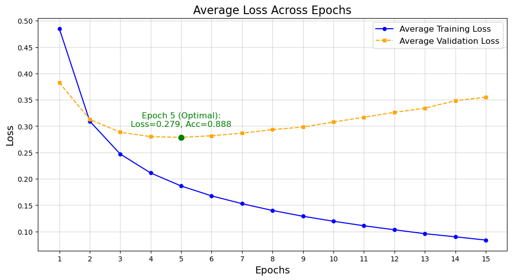

Figure 1: Average Loss Across Epochs for Small Model

```python
# Plot average loss across epochs for small model
plot_average_history(small_model_histories, metric='loss')
```

To address overfitting risks, regularization is applied subsequently.

## 8 Exploring Bigger Models

The exploration of larger models focuses on evaluating the impact of increasing the capacity of the small model. The capacity of neural networks is determined by the number of hidden layers and units. The goal of these modifications is to assess whether increasing the model’s depth or the number of neurons improves performance compared to the baseline single-layer architecture.

### 8.1 Based on Hidden Layers

First, larger models with 2 and 3 hidden layers, using `relu` activation functions and consistent architectural configurations, are tested. Second, models with varying numbers of hidden units are evaluated. A summary of the results is provided in Table 3.

```python
# Define layer configurations for the bigger models
layer_configs = [
    # Model 2 with two layers of 16 neurons each
    [(16, 'relu'), (16, 'relu')],
    # Model 3 with three layers of 16 neurons each
    [(16, 'relu'), (16, 'relu'), (16, 'relu')]
]

# Initialize lists to store results
model_names = ['Small Model (1 h-layer)', 'Model 2 (2 h-layers)', 'Model 3 (3 h-layers)']

# Store average accuracies and losses
average_accuracies = [small_model_average_accuracy]
average_losses = [small_model_average_loss]

# Loop over the different layer configurations and evaluate each model
for layers_config in layer_configs:
    # Train and evaluate the model using 5-Fold CV
    average_accuracy, histories = k_fold_cross_validation(
        model_builder=lambda: build_fcnn(
            input_shape=input_shape,
            layers_config=layers_config,
            output_neurons=1,
            output_activation='sigmoid',
            optimizer='rmsprop',
            loss='binary_crossentropy',
            metrics=['accuracy']
        ),
        x_data=x_train,
        y_data=y_train,
        n_splits=5,
        epochs=15,
        batch_size=512
    )

    # Calculate the average validation loss
    average_loss = np.mean([np.mean(history['val_loss']) for history in histories])

    # Calculate the average validation accuracy
    average_accuracy = np.mean([np.mean(history['val_accuracy']) for history in histories])

    # Append the average accuracy and loss for each model
    average_accuracies.append(average_accuracy)
    average_losses.append(average_loss)
```

```python
# Collect the results in a dictionary for display in a table
accuracy_loss_data = {
    'Model': model_names,
    'Average Val. Loss': average_losses,
    'Average Val. Accuracy': average_accuracies,
}

# Convert the dictionary into a DataFrame
accuracy_loss_df = pd.DataFrame(accuracy_loss_data)

# Convert the table in html format
table_3 = accuracy_loss_df.round(3).to_html(classes='table table-bordered table-striped', index=False)

# Display Table 3
display(HTML(table_3))
```

Table 3: Comparison of Models with Different Layer Configurations

| Model | Average Val. Loss | Average Val. Accuracy |
| --- | --- | --- |
| Small Model (1 h-layer) | 0.313 | 0.882 |
| Model 2 (2 h-layers) | 0.362 | 0.878 |
| Model 3 (3 h-layers) | 0.388 | 0.876 |

As expected, increasing the number of hidden layers leads to a decrease in performance.

### 8.2 Based on Hidden Units

In this phase, the number of neurons in a single layer is increased incrementally, from 16 to 32 and then to 64. Table 4 presents the comparison of model average loss and accuracy for these configurations.

```python
# Define different neuron configurations
neuron_configs = [32, 64]

# Store the results, starting with the small model
results_hu = [
    [16, round(small_model_average_loss, 3), round(small_model_average_accuracy, 3)]
]


# Evaluate each configuration using 5-Fold Cross Validation
for neurons in neuron_configs:
    # Set up the layer configuration for the current number of neurons
    layers_config = [(neurons, 'relu')]

    # Train the model using k-fold cross-validation
    average_accuracy, histories = k_fold_cross_validation(
        model_builder=lambda: build_fcnn(
            input_shape=input_shape,
            layers_config=layers_config,
            output_neurons=1,
            output_activation='sigmoid',
            optimizer='rmsprop',
            loss='binary_crossentropy',
            metrics=['accuracy']
        ),
        x_data=x_train,
        y_data=y_train,
        n_splits=5,
        epochs=15,
        batch_size=512
    )

    # Calculate the average validation loss from all folds
    average_loss = np.mean([np.mean(history['val_loss']) for history in histories])

    # Append the results for the current configuration
    results_hu.append([neurons, round(average_loss, 3), round(average_accuracy, 3)])
```

```python
# Store the results in a dictionary for creating a DataFrame
results_dict = {
    "Hidden Units": [row[0] for row in results_hu],
    "Average Val. Loss": [row[1] for row in results_hu],
    "Average Val. Accuracy": [row[2] for row in results_hu]
}

# Convert the dictionary into a pandas DataFrame
results_hu_df = pd.DataFrame(results_dict)

# Convert the table in html format
table_4 = results_hu_df.to_html(classes='table table-bordered table-striped', index=False)

# Display Table 4
display(HTML(table_4))
```

Table 4: Comparison of Average Loss and Accuracy Across Models

| Hidden Units | Average Val. Loss | Average Val. Accuracy |
| --- | --- | --- |
| 16 | 0.313 | 0.882 |
| 32 | 0.318 | 0.876 |
| 64 | 0.322 | 0.875 |

Table 4 also reveals that a higher number of neurons results in greater loss and lower average accuracy. This could be attributed to the fact that, without expanding the dataset, a larger number of trainable parameters negatively impacts performance.

In summary, these tests demonstrate that with the size of the dataset used, larger models, whether with more hidden units or greater depth, are not always the key to better performance. Starting with a smaller model should always be the first step before scaling up.

This suggests that, without an increase in the number of observations, a simpler model is preferable, aligning with Occam’s razor principle of favoring simpler solutions when additional complexity does not yield substantial benefits.

## 9 Regularization

To mitigate overfitting, several regularization techniques are applied. Dropout, with a rate of 0.5 as recommended by Chollet (2018), randomly excludes 50% of hidden units during training, which helps prevent overfitting by reducing co-adaptation (Hinton et al. 2012). Additionally, L1 and L2 regularization techniques (Jain 2018) are also tested, using the default TensorFlow Keras values of 0.01. L1 promotes sparsity by penalizing large weights, while L2 discourages excessive weight growth. As shown in Table 5, dropout is the only technique that reduces validation loss, whereas L1 and L2 increase it.

```python
# Small model with Dropout
dropout_rate=0.5
small_model_with_dropout_avg_acc, small_model_with_dropout_histories = k_fold_cross_validation(
    model_builder=lambda: build_fcnn(
        input_shape=input_shape,
        layers_config=layers_config_small_model,
        output_neurons=1,
        output_activation='sigmoid',
        optimizer='rmsprop',
        loss='binary_crossentropy',
        metrics=['accuracy'],
        dropout_rate=dropout_rate,
        dropout_after_layers=[True]
    ),
    x_data=x_train,
    y_data=y_train,
    n_splits=5,
    epochs=15,
    batch_size=512
)

# Small model with L1
l1_factor = 0.01
small_model_with_l1_avg_acc, small_model_with_l1_histories = k_fold_cross_validation(
    model_builder=lambda: build_fcnn(
        input_shape=input_shape,
        layers_config=layers_config_small_model,
        output_neurons=1,
        output_activation='sigmoid',
        optimizer='rmsprop',
        loss='binary_crossentropy',
        metrics=['accuracy'],
        dropout_rate=None,
        l1=l1_factor,
        l2=None
    ),
    x_data=x_train,
    y_data=y_train,
    n_splits=5,
    epochs=15,
    batch_size=512
)

# Small model with L2
l2_factor = 0.01
small_model_with_l2_avg_acc, small_model_with_l2_histories = k_fold_cross_validation(
    model_builder=lambda: build_fcnn(
        input_shape=input_shape,
        layers_config=layers_config_small_model,
        output_neurons=1,
        output_activation='sigmoid',
        optimizer='rmsprop',
        loss='binary_crossentropy',
        metrics=['accuracy'],
        dropout_rate=None,
        l1=None,
        l2=l2_factor
    ),
    x_data=x_train,
    y_data=y_train,
    n_splits=5,
    epochs=15,
    batch_size=512
)
```

```python
# Function to calculate average accuracy and loss
def calculate_avg_metrics(histories):
    avg_accuracy = np.mean([np.mean(history['val_accuracy']) for history in histories])
    avg_loss = np.mean([np.mean(history['val_loss']) for history in histories])
    return avg_accuracy, avg_loss

# Collect the model names and histories
models_histories = {
    "Small Model (No Dropout)": small_model_histories,
    "Small Model (With Dropout)": small_model_with_dropout_histories,
    "Small Model (With L1 Regularization)": small_model_with_l1_histories,
    "Small Model (With L2 Regularization)": small_model_with_l2_histories,
}

# Store results
model_names = []
average_accuracies = []
average_losses = []

# Calculate metrics for each model
for model_name, histories in models_histories.items():
    model_names.append(model_name)
    avg_accuracy, avg_loss = calculate_avg_metrics(histories)
    average_accuracies.append(avg_accuracy)
    average_losses.append(avg_loss)
```

```python
# Organize data into a dictionary
accuracy_loss_data = {
    'Model': model_names,
    'Average Val. Loss': average_losses,
    'Average Val. Accuracy': average_accuracies
}

# Convert the dictionary into a pandas DataFrame
accuracy_loss_df = pd.DataFrame(accuracy_loss_data)

# # Convert the table in html format
table_5 = accuracy_loss_df.round(3).to_html(classes='table table-bordered table-striped', index=False)

# Display Table 5
display(HTML(table_5))
```

Table 5: Comparison of the Small Model With and Without Regularization

| Model | Average Val. Loss | Average Val. Accuracy |
| --- | --- | --- |
| Small Model (No Dropout) | 0.313 | 0.882 |
| Small Model (With Dropout) | 0.299 | 0.886 |
| Small Model (With L1 Regularization) | 1.501 | 0.695 |
| Small Model (With L2 Regularization) | 0.415 | 0.866 |

Additionally, Figure 2 illustrates that the reduction in loss with dropout is accompanied by a shift to a more optimal epoch, highlighting a trade-off between performance and computational cost. In contrast, both L1 and L2 regularization underperform compared to the dropout and no-dropout models. They require more epochs to reach optimal performance and result in higher validation loss, suggesting they are not suitable regularization techniques for this problem. However, it is worth noting that this conclusion is based on the use of default parameter values for L1 and L2 regularization.

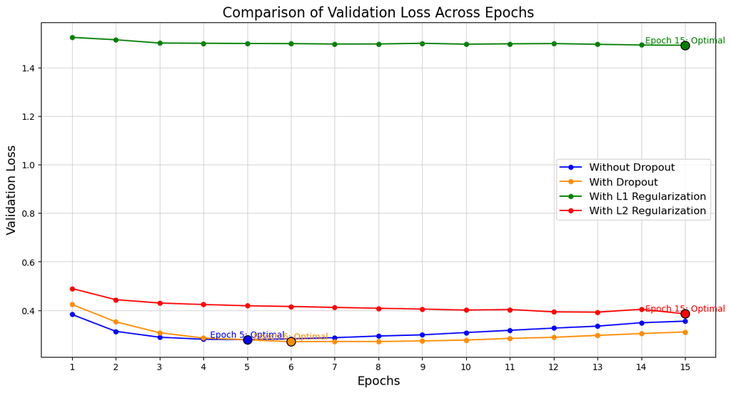

Figure 2: Validation Loss Comparison Across Regularization Strategies

```python
# Function to plot model validation loss and optimal points
def plot_validation_loss(avg_val_losses, optimal_epochs,
                         optimal_losses, colors, labels, figure_counter):
    plt.figure(figsize=(14, 7))

    # Plot each model
    for avg_loss, optimal_epoch, optimal_loss, color, label in zip(avg_val_losses, optimal_epochs,
                        optimal_losses, colors, labels):
        plt.plot(avg_loss, label=label, color=color,
                 linestyle='-', marker='o', markersize=5)
        plt.scatter(optimal_epoch - 1, optimal_loss, color=color,
                    edgecolor='black', zorder=5, s=100)
        plt.text(optimal_epoch - 1, optimal_loss + 0.01,
                 f'Epoch {optimal_epoch}: Optimal',
                 color=color, fontsize=10, ha='center')

    # Add plot labels and legend
    plt.title('Comparison of Validation Loss Across Epochs',
              fontsize=16)
    plt.xlabel('Epochs', fontsize=14)
    plt.ylabel('Validation Loss', fontsize=14)
    plt.grid(alpha=0.5)
    plt.legend(loc='best', fontsize=12)
    plt.xticks(ticks=np.arange(len(avg_val_losses[0])),
               labels=np.arange(1, len(avg_val_losses[0]) + 1))

    # Display plot
    plt.show()

# Prepare data for plotting
avg_val_losses_reg = [
    np.mean([history['val_loss'] for history in small_model_histories],
            axis=0),
    np.mean([history['val_loss'] for history in small_model_with_dropout_histories],
            axis=0),
    np.mean([history['val_loss'] for history in small_model_with_l1_histories],
            axis=0),
    np.mean([history['val_loss'] for history in small_model_with_l2_histories],
            axis=0)
]
optimal_epochs = [
    np.argmin(avg_val_losses_reg[0]) + 1,
    np.argmin(avg_val_losses_reg[1]) + 1,
    np.argmin(avg_val_losses_reg[2]) + 1,
    np.argmin(avg_val_losses_reg[3]) + 1
]
optimal_losses = [loss[epoch - 1] for loss, epoch in zip(avg_val_losses_reg,
                                                         optimal_epochs)]

# Plot validation loss comparison across regularization strategies
plot_validation_loss(avg_val_losses_reg, optimal_epochs, optimal_losses,
                     ['blue', 'darkorange', 'green', 'red'],
                     ['Without Dropout', 'With Dropout',
                      'With L1 Regularization', 'With L2 Regularization'],
                     figure_counter)
```

## 10 Hyperparameter Tuning

Lastly, before evaluating the model, hyperparameter tuning is conducted. This process involves two approaches: first, adjusting the batch size, and second, exploring various learning rates using a grid search. The objective is to identify the optimal configuration that maximizes model performance and generalization, ensuring the best possible setup prior to the final evaluation.

### 10.1 Adjusting Batch Size

```python
# Define different batch sizes
batch_sizes = [256, 1024]
# Store the results, starting with the small model
results_batch_size = [
    [512, round(small_model_average_loss, 3), round(small_model_average_accuracy, 3)]
]

# Evaluate each batch size
for batch_size in batch_sizes:
    # Train the model
    average_accuracy, histories = k_fold_cross_validation(
        model_builder=lambda: build_fcnn(
            input_shape=input_shape,
            layers_config=[(16, 'relu')],
            output_neurons=1,
            output_activation='sigmoid',
            optimizer='rmsprop',
            dropout_rate=dropout_rate,
            loss='binary_crossentropy',
            metrics=['accuracy']
        ),
        x_data=x_train,
        y_data=y_train,
        n_splits=5,
        epochs=15,
        batch_size=batch_size
    )

    # Calculate the average validation loss from all folds
    average_loss = np.mean([np.mean(history['val_loss']) for history in histories])

    # Calculate the average validation accuracy
    average_accuracy = np.mean([np.mean(history['val_accuracy']) for history in histories])

    # Append the results for the current configuration
    results_batch_size.append([batch_size, round(average_loss, 3),
                               round(average_accuracy, 3)])

# Store the results in a dictionary for creating a DataFrame
results_batch_size_dict = {
    "Batch Size": [row[0] for row in results_batch_size],
    "Average Val. Loss": [row[1] for row in results_batch_size],
    "Average Val. Accuracy": [row[2] for row in results_batch_size],
}
```

```python
# Convert the dictionary into a pandas DataFrame
results_batch_size_df = pd.DataFrame(results_batch_size_dict).sort_values(by="Batch Size")

# Convert the table in html format
table_6 = results_batch_size_df.to_html(classes='table table-bordered table-striped', index=False)

# Display Table 6
display(HTML(table_6))
```

Table 6: Comparison of Average Loss and Accuracy Across Batch Sizes

| Batch Size | Average Val. Loss | Average Val. Accuracy |
| --- | --- | --- |
| 256 | 0.311 | 0.887 |
| 512 | 0.313 | 0.882 |
| 1024 | 0.304 | 0.885 |

### 10.2 Varying the Learning Rate

Widely regarded as the most critical hyperparameter (Goodfellow, Bengio, and Courville 2016), the learning rate determines the magnitude of model weight updates in response to the estimated error during training. This parameter typically takes values within the range of 0.0 to 1.0 (Brownlee 2020a). For practicality and to minimize computational resources, three learning rates are tested: the default value of 0.001, along with 0.005 and 0.01, as shown in Table 7.

```python
# Define different learning rates
learning_rates = [0.01, 0.005]
# Store the results, starting with the small model
results_lr = [
    [0.001, round(small_model_average_loss, 3), round(small_model_average_accuracy, 3)]
]

# Evaluate each learning rate
for lr in learning_rates:
    # Train the model
    average_accuracy, histories = k_fold_cross_validation(
        model_builder=lambda: build_fcnn(
            input_shape=input_shape,
            layers_config=[(16, 'relu')],
            output_neurons=1,
            output_activation='sigmoid',
            optimizer='rmsprop',
            dropout_rate=dropout_rate,
            learning_rate=lr,
            loss='binary_crossentropy',
            metrics=['accuracy']
        ),
        x_data=x_train,
        y_data=y_train,
        n_splits=5,
        epochs=15,
        batch_size=512
    )

    # Calculate the average validation loss from all folds
    average_loss = np.mean([np.mean(history['val_loss']) for history in histories])

    # Append the results for the current configuration
    results_lr.append([lr, round(average_loss, 3),
                    round(average_accuracy, 3)])

# Store the results in a dictionary for creating a DataFrame
results_dict = {
    "Learning Rate": [row[0] for row in results_lr],
    "Average Val. Loss": [row[1] for row in results_lr],
    "Average Val. Accuracy": [row[2] for row in results_lr],
}
```

```python
# Convert the dictionary into a pandas DataFrame
results_lr_df = pd.DataFrame(results_dict).sort_values(by="Learning Rate")

# Convert the table in html format
table_7 = results_lr_df.to_html(classes='table table-bordered table-striped', index=False)

# Display Table 7
display(HTML(table_7))
```

Table 7: Comparison of Average Loss and Accuracy Across Learning Rates

| Learning Rate | Average Val. Loss | Average Val. Accuracy |
| --- | --- | --- |
| 0.001 | 0.313 | 0.882 |
| 0.005 | 0.366 | 0.880 |
| 0.010 | 0.386 | 0.879 |

The results in Table 7 indicate that the lowest learning rate of 0.001 achieved the best performance, with the lowest validation loss and the highest validation accuracy. Higher learning rates (0.005 and 0.01) resulted in increased loss and reduced accuracy, likely due to the optimizer overshooting the optimal point in the loss landscape. Consequently, a learning rate of 0.001 was selected as the optimal choice for this study. Future research could explore testing different learning rates with finer increments and incorporating momentum to stabilize optimization and further improve performance.

## 11 Testing and Conclusion

Finally, the model is retrained on the complete training dataset using the previously identified optimal hyperparameters and evaluated on the test set.

```python
# Optimal hyperparameters from experiments
final_neurons = 16
# Optimal epoch when dropout is used
final_epochs = np.argmin(avg_val_losses_reg[1]) + 1
final_batch_size = 1024

# Build the final model with optimal parameters
final_model = build_fcnn(
    input_shape=input_shape,
    layers_config=[(final_neurons, 'relu')],
    output_neurons=1,
    output_activation='sigmoid',
    dropout_rate=dropout_rate,
    optimizer='rmsprop',
    loss='binary_crossentropy',
    metrics=['accuracy']
)

# Train the model on the entire training data
history = final_model.fit(
    x_train, y_train,
    epochs=final_epochs,
    batch_size=final_batch_size,
    verbose=1
)

# Evaluate the model on the test set
test_loss, test_accuracy = final_model.evaluate(x_test, y_test, verbose=0)

# Display final test performance
print(f"Final Test Loss: {test_loss:.3f}")
print(f"Final Test Accuracy: {test_accuracy:.3f}")
```

```
25/25 ━━━━━━━━━━━━━━━━━━━━ 6s 89ms/step - accuracy: 0.6607 - loss: 0.6141
25/25 ━━━━━━━━━━━━━━━━━━━━ 2s 53ms/step - accuracy: 0.8416 - loss: 0.4192
25/25 ━━━━━━━━━━━━━━━━━━━━ 1s 48ms/step - accuracy: 0.8704 - loss: 0.3516
25/25 ━━━━━━━━━━━━━━━━━━━━ 2s 66ms/step - accuracy: 0.8876 - loss: 0.3091
25/25 ━━━━━━━━━━━━━━━━━━━━ 2s 68ms/step - accuracy: 0.8996 - loss: 0.2810
25/25 ━━━━━━━━━━━━━━━━━━━━ 1s 29ms/step - accuracy: 0.9051 - loss: 0.2590
Final Test Loss: 0.283
Final Test Accuracy: 0.887
```

In conclusion, this study highlights the importance of starting with a simple model and progressively optimizing its capacity, applying regularization techniques to reduce the risk of overfitting and fine-tuning hyperparameters when working with deep learning. While not achieving state-of-the-art results, the final model demonstrates reasonable performance given the small scale of both the dataset and the model. These findings underscore the potential of deep learning techniques for binary sentiment classification, though more effective models for this problem are available. Future research could explore extending the IMDB dataset, experimenting with alternative neural network architectures and incorporating diverse evaluation metrics to further improve performance, as demonstrated in the works of Jang et al. (2020), Semary et al. (2023) and Tan et al. (2023).

## 12 References

Abadi, M., A. Agarwal, P. Barham, E. Brevdo, Z. Chen, C. Citro, G. S. Corrado, A. Davis, J. Dean, et al. 2015. “TensorFlow: Large-Scale Machine Learning on Heterogeneous Systems.” https://www.tensorflow.org.

Basuroy, S., S. Chatterjee, and S. A. Ravid. 2003. “How Critical Are Critical Reviews? The Box Office Effects of Film Critics, Star Power, and Budgets.” *Journal of Marketing* 67 (4): 103–17. https://doi.org/10.1509/jmkg.67.4.103.18692.

Bishop, C. M., and H. Bishop. 2024. *Deep Learning: Foundations and Concepts*. 1st ed. Cham: Springer. https://doi.org/10.1007/978-3-031-45468-4.

Brownlee, J. 2020a. “Understand the Impact of Learning Rate on Neural Network Performance.” https://machinelearningmastery.com/understand-the-dynamics-of-learning-rate-on-deep-learning-neural-networks/.

———. 2020b. “How to Control the Speed and Stability of Training Neural Networks with Gradient Descent and Batch Size.” Machine Learning Mastery. https://machinelearningmastery.com/how-to-control-the-speed-and-stability-of-training-neural-networks-with-gradient-descent-batch-size/.

Chollet, F. 2018. *Deep Learning with Python*. 1st ed. Shelter Island, NY: Manning Publications.

Glorot, X., and Y. Bengio. 2010. “Understanding the Difficulty of Training Deep Feedforward Neural Networks.” In *Proceedings of the Thirteenth International Conference on Artificial Intelligence and Statistics*, 9:249–56. PMLR.

Goodfellow, I., Y. Bengio, and A. Courville. 2016. *Deep Learning*. MIT Press.

Hastie, T., R. Tibshirani, and J. Friedman. 2009. *The Elements of Statistical Learning: Data Mining, Inference, and Prediction*. 2nd ed. Springer.

Hinton, G. E., N. Srivastava, A. Krizhevsky, I. Sutskever, and R. Salakhutdinov. 2012. “Improving Neural Networks by Preventing Co-Adaptation of Feature Detectors.” *CoRR* abs/1207.0580.

Jain, S. 2018. “Fundamentals of Deep Learning: Regularization Techniques.” https://www.analyticsvidhya.com/blog/2018/04/fundamentals-deep-learning-regularization-techniques/.

James, G., D. Witten, T. Hastie, and R. Tibshirani. 2013. *An Introduction to Statistical Learning: With Applications in r*. Springer.

Jang, B., M. Kim, G. Harerimana, S. U. Kang, and J. W. Kim. 2020. “Bi-LSTM Model to Increase Accuracy in Text Classification: Combining Word2vec, CNN, and Attention Mechanism.” *Applied Sciences*. https://doi.org/10.3390/app10175841.

Jurafsky, D., and J. H. Martin. 2024. *Speech and Language Processing: An Introduction to Natural Language Processing, Computational Linguistics, and Speech Recognition with Language Models*. 3rd ed. https://web.stanford.edu/~jurafsky/slp3.

Maas, A. L., R. E. Daly, P. T. Pham, D. Huang, A. Y. Ng, and C. Potts. 2011. “Learning Word Vectors for Sentiment Analysis.” In *Proceedings of the 49th Annual Meeting of the Association for Computational Linguistics: Human Language Technologies*, 142–50. Portland, Oregon, USA: Association for Computational Linguistics. http://www.aclweb.org/anthology/P11-1015.

Manning, C. D., and H. Schütze. 1999. *Foundations of Statistical Natural Language Processing*. MIT Press.

Pentheny, J. R. 2015. “The Influence of Movie Reviews on Consumers.” Honors Theses; Capstones.

Provost, F., and T. Fawcett. 2013. *Data Science for Business: What You Need to Know about Data Mining and Data-Analytic Thinking*. O’Reilly Media.

Semary, N., W. Ahmed, K. Amin, P. Pławiak, and M. Hammad. 2023. “Improving Sentiment Classification Using a RoBERTa-Based Hybrid Model.” *Frontiers in Human Neuroscience* 17. https://doi.org/10.3389/fnhum.2023.1292010.

Tan, K. L., C. P. Lee, and K. M. Lim. 2023. “RoBERTa-GRU: A Hybrid Deep Learning Model for Enhanced Sentiment Analysis.” *Applied Sciences*. https://doi.org/10.3390/app13063915.

Vidhya, Analytics. 2021. “Metrics to Evaluate Your Classification Model to Take the Right Decisions.” https://www.analyticsvidhya.com/blog/2021/07/metrics-to-evaluate-your-classification-model-to-take-the-right-decisions/.

© 2024 Goldsmiths, University of London. This document is part of an academic coursework project and is licensed under the Creative Commons Attribution-NonCommercial-NoDerivatives 4.0 International License CC BY-NC-ND 4.0. You may share this work, but please provide appropriate credit, and do not use it for commercial purposes or create derivative works.